# Chapter 3 HW

Nehemya McCarter-Ribakoff

28 February 2017

## Conceptual Questions

#### Exercise 1: Describe the null hypotheses to which the p-values given in Table 3.4 correspond. Explain what conclusions you can draw based on these p-values. Your explanation should be phrased in terms of sales, TV, radio, and newspaper, rather than in terms of the coefficients of the linear model.

Null Hypotheses:

TV: There is no relationship between TV advertising and sales. The p-value is below 0.01, so we may reject the null hypothesis. That is, there is some relationship between TV ads and sales.

radio: There is no relationship between radio advertising and sales. The p-value is below 0.01, so we may reject the null hypothesis. That is, there is some relationship between radio ads and sales.

newspaper: There is not relationship between newspaper advertising and sales. The p-value is about 0.86, which is quite high. Thus, we may retain the null hypothesis. There is no relationship between newspaper ads and sales.

#### Exercise 3: suppose we have a data set with five predictors, X1 = GPA, X2 = IQ, X3 = Gender (1 for Female and 0 for Male), X4 = Interaction between GPA and IQ, and X5 = Interaction between GPA and Gender. The response is starting salary after graduation (in thousands of dollars). suppose we use least squares to fit the model, and get β<sub>0</sub> = 50, β<sub>1</sub> = 20, β<sub>2</sub> = 0.07, β<sub>3</sub> = 35, β<sub>4</sub> = 0.01, β<sub>5</sub> = −10.

Our intercept coefficient is 50, so our average salary is $50,000.

male: (gender = 0) 50 + 20 k<sub>1</sub> + 0.07 k<sub>2</sub> + 0.01(k<sub>1</sub> * k<sub>2</sub>)

female: (gender = 1) 50 + 20 k<sub>1</sub> + 0.07 k<sub>2</sub> + 35 + 0.01(k<sub>1</sub> * k<sub>2</sub>) - 10k<sub>1</sub>

**(a) Which answer is correct, and why?**

**i. For a fixed value of IQ and GPA, males earn more on average than females.**

**ii. For a fixed value of IQ and GPA, females earn more on average than males.**

**iii. For a fixed value of IQ and GPA, males earn more on average than females provided that the GPA is high enough.**

**iv. For a fixed value of IQ and GPA, females earn more on average than males provided that the GPA is high enough.**

Let’s take a look at output of each function for some given values of IQ and GPA.

GPA (k<sub>1</sub>): 4.0

IQ (k<sub>2</sub>): 120

male: (gender = 0) 50 + 20(4.0) + 0.07(120) + 0.01(4.0 * 120)

female: (gender = 1) 50 + 20(4.0) + 0.07(120) + 35 + 0.01(4.0 * 120) - 10(4.0)

male = 143.2 female = 138.2

At equal values for IQ and GPA, males earn more than females. i is correct, ii is false. Since males already earn more than females, iii is also false.

Interaction between GPA and gender has a negative coefficient, so iv does not make sense.

**(b) Predict the salary of a female with IQ of 110 and a GPA of 4.0.**

We simply multiply the predictors to the model’s corresponding coefficients.

```
50 + (20 * 4.0) + (0.07 * 110) + 35 + (0.01 * 4.0 * 110) - (10 * 4.0)
```

We expect her to have a salary of $137,10.

**(c) True or false: Since the coefficient for the GPA/IQ interaction term is very small, there is very little evidence of an interaction effect. Justify your answer.**

This is false. A coefficient tells us the intensity of the interaction. It has little bearing on its statistical significance. We must look at the p-value of the coefficient to determine this.

## Applied Questions

#### Exercise 10: This question should be answered using the Carseats data set.

```r
library(ISLR)
# Let's get the names so we know what we're doing
names(Carseats)
```

```
##  [1] "Sales"       "CompPrice"   "Income"      "Advertising" "Population"
##  [6] "Price"       "ShelveLoc"   "Age"         "Education"   "Urban"
## [11] "US"
```

```r
#Note that unit sales are in $1,000.
```

**(a) Fit a multiple regression model to predict Sales using Price, Urban, and US.**

```r
lm.fit = lm(Carseats$Sales~Carseats$Price+Carseats$Urban+Carseats$US)
lm.fit
```

```
##
## Call:
## lm(formula = Carseats$Sales ~ Carseats$Price + Carseats$Urban +
##     Carseats$US)
##
## Coefficients:
##       (Intercept)     Carseats$Price  Carseats$UrbanYes
##          13.04347           -0.05446           -0.02192
##    Carseats$USYes
##           1.20057
```

**(b) Provide an interpretation of each coefficient in the model. Be careful—some of the variables in the model are qualitative!**

Our Intercept is 13.04 – when all predictors are averaged, we can expect sales of $13,040

The coefficient of price is -0.05446. As price increases, sales marginally decrease.

Stores in urban locations exhibit marginally lower sales. Important to note that -0.022 is quite a small coefficient.

There is a small, positive relationship between a U.S. store location and an increase in sales.

**(c) Write out the model in equation form, being careful to handle the qualitative variables properly.**

Sales = β<sub>0</sub> + β<sub>1</sub>Price + β<sub>2</sub>UrbanYes + β<sub>3</sub>USYes

**(d) For which of the predictors can you reject the null hypothesis H0 : β<sub>j</sub> = 0?**

We must look at the p-values

```r
summary(lm.fit)
```

```
##
## Call:
## lm(formula = Carseats$Sales ~ Carseats$Price + Carseats$Urban +
##     Carseats$US)
##
## Residuals:
##     Min      1Q  Median      3Q     Max
## -6.9206 -1.6220 -0.0564  1.5786  7.0581
##
## Coefficients:
##                    Estimate Std. Error t value Pr(>|t|)
## (Intercept)       13.043469   0.651012  20.036  < 2e-16 ***
## Carseats$Price    -0.054459   0.005242 -10.389  < 2e-16 ***
## Carseats$UrbanYes -0.021916   0.271650  -0.081    0.936
## Carseats$USYes     1.200573   0.259042   4.635 4.86e-06 ***
## ---
## Signif. codes:  0 '***' 0.001 '**' 0.01 '*' 0.05 '.' 0.1 ' ' 1
##
## Residual standard error: 2.472 on 396 degrees of freedom
## Multiple R-squared:  0.2393, Adjusted R-squared:  0.2335
## F-statistic: 41.52 on 3 and 396 DF,  p-value: < 2.2e-16
```

**(e) On the basis of your response to the previous question, fit a smaller model that only uses the predictors for which there is evidence of association with the outcome.**

```r
lm.smallFit = lm(Carseats$Sales~Carseats$Price + Carseats$US)
```

**(f) How well do the models in (a) and (e) fit the data?**

```r
summary(lm.fit)$sigma #RSE fit
```

```
## [1] 2.472492
```

```r
summary(lm.smallFit)$sigma #RSE smallFit
```

```
## [1] 2.469397
```

```r
summary(lm.fit)$r.sq #R^2 fit
```

```
## [1] 0.2392754
```

```r
summary(lm.smallFit)$r.sq #R^2 smallFit
```

```
## [1] 0.2392629
```

The models fit the data about the same, though the original fit has a larger R<sub>2</sub>, so it is a slightly better fit. Both are much closer to 0 than 1, so neither is a very good fit.

**(g) Using the model from (e), obtain 95% confidence intervals for the coefficient(s).**

```r
confint(lm.smallFit, level = 0.95)
```

```
##                      2.5 %      97.5 %
## (Intercept)    11.79032020 14.27126531
## Carseats$Price -0.06475984 -0.04419543
## Carseats$USYes  0.69151957  1.70776632
```

**(h) Is there evidence of outliers or high leverage observations in the model from (e)?**

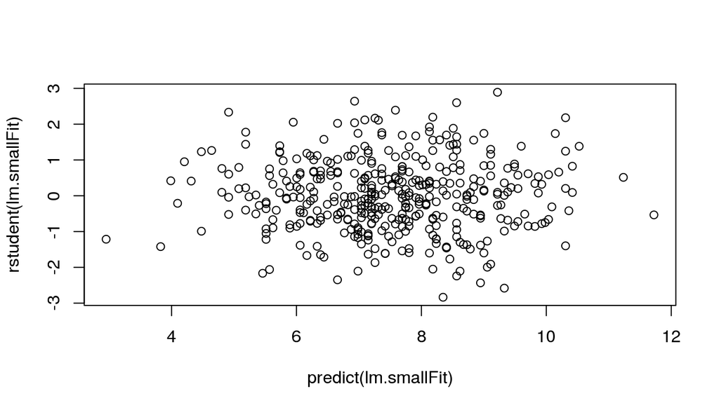

```r
plot(predict(lm.smallFit), rstudent(lm.smallFit))
```

Studentized residuals fall between -3 and 3, so we do not appear to have outliers.

#### Exercise 13: In this exercise you will create some simulated data and will fit simple linear regression models to it. Make sure to use set.seed(1) prior to starting part (a) to ensure consistent results.

seed(1)

**(a) Using the rnorm() function, create a vector, x, containing 100 observations drawn from a N(0, 1) distribution. This represents a feature, X.**

```r
x = rnorm(100, mean = 0, sd = 1)
```

**(b) Using the rnorm() function, create a vector, eps, containing 100 observations drawn from a N(0, 0.25) distribution i.e. a normal distribution with mean zero and variance 0.25.**

```r
eps = rnorm(100, mean = 0, sd = sqrt(0.25))
```

**(c) Using x and eps, generate a vector y according to the model**

**Y = −1+0.5X + ε**

**What is the length of the vector y? What are the values of β<sub>0</sub> and β<sub>1</sub> in this linear model?**

```r
Y = -1 + (0.5 * x) + eps
length(Y)
```

```
## [1] 100
```

The length of Y is 100. β<sub>0</sub> = -1 and β<sub>1</sub> = 0.5

**(d) Create a scatterplot displaying the relationship between x and y. Comment on what you observe.**

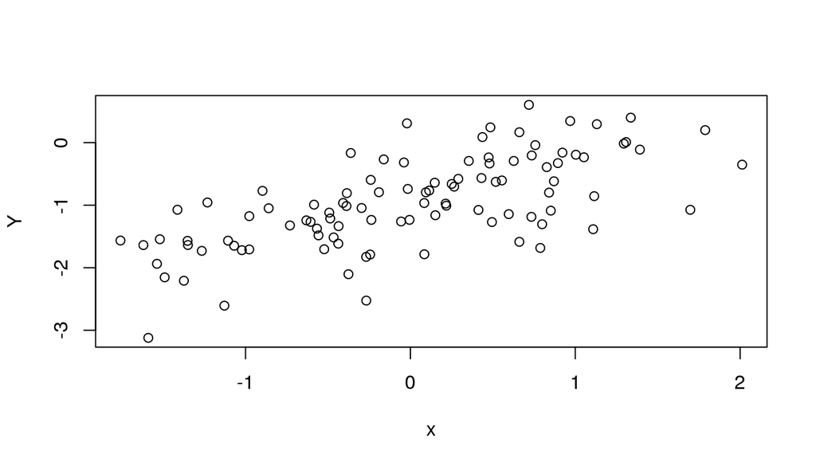

```r
plot(x, Y)
```

There is a general positive relationship between x and Y

**(e) Fit a least squares linear model to predict y using x. Comment on the model obtained. How do β<sub>0</sub> and β<sub>1</sub> compare to β^<sub>0</sub> and β^<sub>1</sub>?**

```r
ls.fit = lm(Y~x)
summary(ls.fit)
```

```
##
## Call:
## lm(formula = Y ~ x)
##
## Residuals:
##      Min       1Q   Median       3Q      Max
## -1.42030 -0.29084  0.07494  0.29626  1.27702
##
## Coefficients:
##             Estimate Std. Error t value Pr(>|t|)
## (Intercept) -0.95658    0.05402 -17.707  < 2e-16 ***
## x            0.55439    0.06240   8.885 3.18e-14 ***
## ---
## Signif. codes:  0 '***' 0.001 '**' 0.01 '*' 0.05 '.' 0.1 ' ' 1
##
## Residual standard error: 0.5402 on 98 degrees of freedom
## Multiple R-squared:  0.4461, Adjusted R-squared:  0.4405
## F-statistic: 78.94 on 1 and 98 DF,  p-value: 3.175e-14
```

β^<sub>0</sub> is closer to 0 than β<sub>0</sub>

β^<sub>1</sub> > β<sub>1</sub>

**(f) Display the least squares line on the scatterplot obtained in (d). Draw the population regression line on the plot, in a different color. Use the legend() command to create an appropriate legend.**

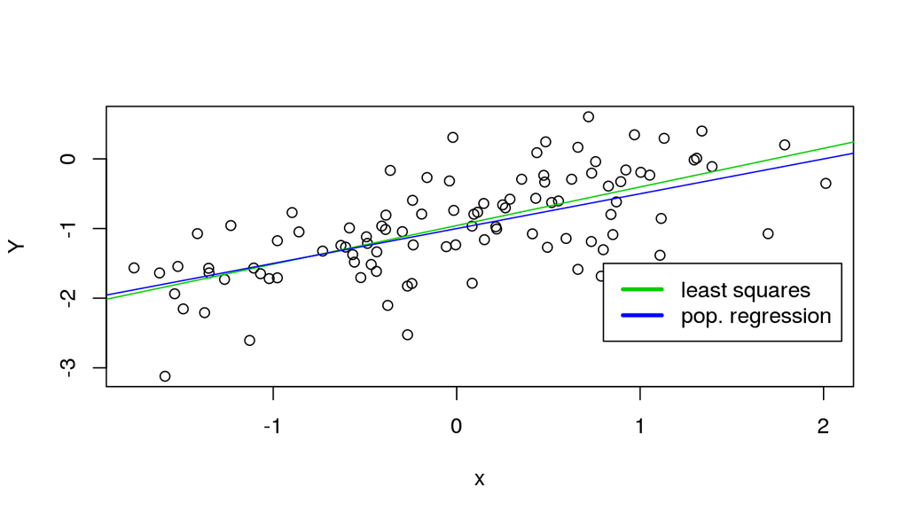

```r
plot(x, Y)
abline(ls.fit, col = 3)
abline(-1, 0.5, col = 4)
legend(0.8,-1.5, legend = c("least squares", "pop. regression"), col=3:4, lwd = 3)
```

**(g) Now fit a polynomial regression model that predicts y using x and x<sup>2</sup>. Is there evidence that the quadratic term improves the model fit? Explain your answer.**

```r
lm.fit2 = lm(Y~x + x^2)
summary(lm.fit2)
```

```
##
## Call:
## lm(formula = Y ~ x + x^2)
##
## Residuals:
##      Min       1Q   Median       3Q      Max
## -1.42030 -0.29084  0.07494  0.29626  1.27702
##
## Coefficients:
##             Estimate Std. Error t value Pr(>|t|)
## (Intercept) -0.95658    0.05402 -17.707  < 2e-16 ***
## x            0.55439    0.06240   8.885 3.18e-14 ***
## ---
## Signif. codes:  0 '***' 0.001 '**' 0.01 '*' 0.05 '.' 0.1 ' ' 1
##
## Residual standard error: 0.5402 on 98 degrees of freedom
## Multiple R-squared:  0.4461, Adjusted R-squared:  0.4405
## F-statistic: 78.94 on 1 and 98 DF,  p-value: 3.175e-14
```

**(h) Repeat (a)–(f) after modifying the data generation process in such a way that there is less noise in the data. The model in (c) should remain the same. You can do this by decreasing the variance of the normal distribution used to generate the error term in (b). Describe your results.**

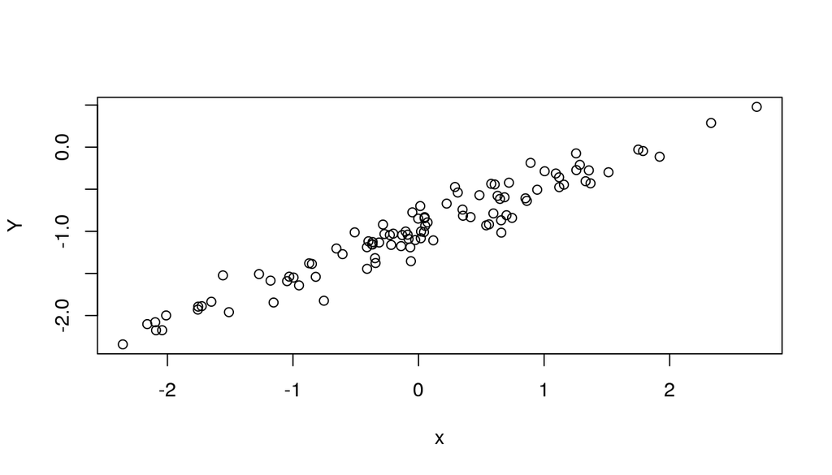

```r
x = rnorm(100, mean = 0, sd = 1)
eps = rnorm(100, mean = 0, sd = sqrt(0.25 / 10))
Y = -1 + (0.5 * x) + eps
# (d) create a scatterplot, comment on observations
plot(x, Y)
```

The shape here is decidedly more linear and uniform. It more cloesly represents a simple regression line.

```r
# (e) fit a least squares linear regression model. Comment
# on the model obtained. How do β^0 and β^1 compare to
# β0 and β1?

ls.fitLessNoise = lm(Y~x)
summary(ls.fitLessNoise)
```

```
##
## Call:
## lm(formula = Y ~ x)
##
## Residuals:
##      Min       1Q   Median       3Q      Max
## -0.43341 -0.10206  0.02323  0.07332  0.35969
##
## Coefficients:
##             Estimate Std. Error t value Pr(>|t|)
## (Intercept) -0.98808    0.01542  -64.08   <2e-16 ***
## x            0.53428    0.01482   36.05   <2e-16 ***
## ---
## Signif. codes:  0 '***' 0.001 '**' 0.01 '*' 0.05 '.' 0.1 ' ' 1
##
## Residual standard error: 0.1542 on 98 degrees of freedom
## Multiple R-squared:  0.9299, Adjusted R-squared:  0.9292
## F-statistic:  1300 on 1 and 98 DF,  p-value: < 2.2e-16
```

For reference,

β<sub>0</sub> = -1

β<sub>1</sub> = 0.5

Both values have decreased, with β^<sub>1</sub> getting closer to 0.

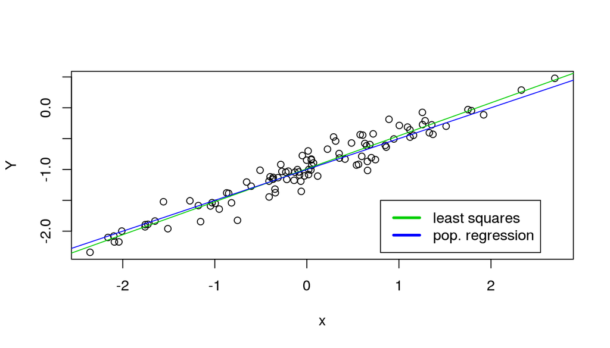

```r
# (f) Display the least squares line on the scatterplot obtained in (d).
# Draw the population regression line on the plot, in a different
# color. Use the legend() command to create an appropriate legend.

plot(x, Y)
abline(ls.fitLessNoise, col = 3)
abline(-1, 0.5, col = 4)
legend(0.8 ,-1.5, legend = c("least squares", "pop. regression"), col=3:4, lwd = 3)
```

**(i) Repeat (a)–(f) after modifying the data generation process in such a way that there is more noise in the data. The model in (c) should remain the same. You can do this by increasing the variance of the normal distribution used to generate the error term in (b). Describe your results.**

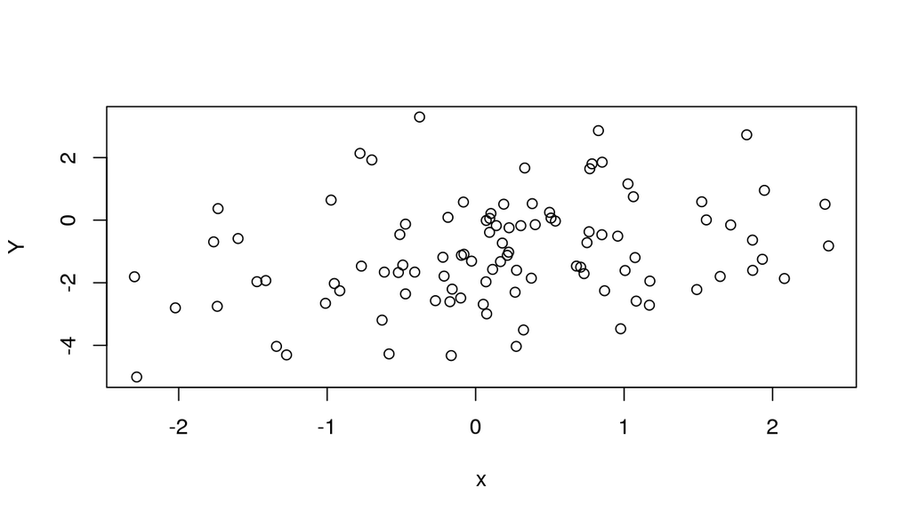

```r
x = rnorm(100, mean = 0, sd = 1)
eps = rnorm(100, mean = 0, sd = sqrt(2.5))
Y = -1 + (0.5 * x) + eps
# (d) create a scatterplot, comment on observations
plot(x, Y)
```

```r
# (e) fit a least squares linear regression model. Comment
# on the model obtained. How do β^0 and β^1 compare to
# β0 and β1?

ls.fitMoreNoise = lm(Y~x)
summary(ls.fitMoreNoise)
```

```
##
## Call:
## lm(formula = Y ~ x)
##
## Residuals:
##     Min      1Q  Median      3Q     Max
## -3.1142 -1.0060 -0.1078  1.0207  4.6100
##
## Coefficients:
##             Estimate Std. Error t value Pr(>|t|)
## (Intercept)  -1.1345     0.1621  -6.998 3.24e-10 ***
## x             0.4758     0.1566   3.038  0.00306 **
## ---
## Signif. codes:  0 '***' 0.001 '**' 0.01 '*' 0.05 '.' 0.1 ' ' 1
##
## Residual standard error: 1.599 on 98 degrees of freedom
## Multiple R-squared:  0.08605,    Adjusted R-squared:  0.07673
## F-statistic: 9.227 on 1 and 98 DF,  p-value: 0.003056
```

For reference,

β<sub>0</sub> = -1 and β<sub>1</sub> = 0.5

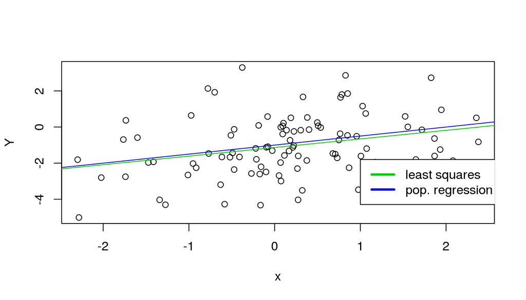

```r
# (f) Display the least squares line on the scatterplot obtained in (d).
# Draw the population regression line on the plot, in a different
# color. Use the legend() command to create an appropriate legend.
plot(x, Y)
abline(ls.fitMoreNoise, col = 3)
abline(-1, 0.5, col = 4)
legend(1,-1.8, legend = c("least squares", "pop. regression"), col=3:4, lwd = 3)
```

**(j) What are the confidence intervals for β<sub>0</sub> and β<sub>1</sub> based on the original data set, the noisier data set, and the less noisy data set? Comment on your results.**

Original data set

```r
confint(ls.fit)
```

```
##                  2.5 %     97.5 %
## (Intercept) -1.0637834 -0.8493709
## x            0.4305646  0.6782151
```

Less noisy data set

```r
confint(ls.fitLessNoise)
```

```
##                  2.5 %     97.5 %
## (Intercept) -1.0186759 -0.9574784
## x            0.5048702  0.5636830
```

More noisy data set

```r
confint(ls.fitMoreNoise)
```

```
##                  2.5 %     97.5 %
## (Intercept) -1.4562372 -0.8127991
## x            0.1649511  0.7865687
```

As we’d expect, the less noisy data set has the most narrow confidence interval, since its data have all been squeezed together. The noisy data set has the widest interval, because its data is scattered everywhere. The original set falls somewhere in between.

## Teamwork report

| Team member | Conceptual | Applied | Contribution % |
| --- | --- | --- | --- |
| Nehemya | Yes | Yes | 100% |
| Total |  |  | 100% |